# Assignment 1 - Exploratory Data Analysis

Author

Chun-Tse Hung

## Step 1

## For each of the two datasets, check the dimensions, headers, footers, variable names and variable types. Check the distribution of the key variable we are analyzing (PM). Write up a summary of all of your findings.

```r
library(leaflet)
library(tidyverse)
data2005 <- read.csv("C:/Users/chuntseh/Downloads/BIOSTAT620W26/data2005.csv")
data2025 <- read.csv("C:/Users/chuntseh/Downloads/BIOSTAT620W26/data2025.csv")

dim(data2005)
```

```
[1] 5280   22
```

```r
dim(data2025)
```

```
[1] 9934   22
```

```r
head(data2005)
```

```
        Date Source   Site.ID POC Daily.Mean.PM2.5.Concentration    Units
1 01/01/2005    AQS 260050003   1                            9.3 ug/m3 LC
2 01/02/2005    AQS 260050003   1                            7.0 ug/m3 LC
3 01/03/2005    AQS 260050003   1                           15.7 ug/m3 LC
4 01/04/2005    AQS 260050003   1                           13.4 ug/m3 LC
5 01/05/2005    AQS 260050003   1                            5.3 ug/m3 LC
6 01/06/2005    AQS 260050003   1                            4.0 ug/m3 LC
  Daily.AQI.Value       Local.Site.Name Daily.Obs.Count Percent.Complete
1              51 966 32nd St (Holland)               1              100
2              39 966 32nd St (Holland)               1              100
3              63 966 32nd St (Holland)               1              100
4              59 966 32nd St (Holland)               1              100
5              29 966 32nd St (Holland)               1              100
6              22 966 32nd St (Holland)               1              100
  AQS.Parameter.Code AQS.Parameter.Description Method.Code
```

[output cut: 27 more lines]

```r
head(data2025)
```

```
        Date Source   Site.ID POC Daily.Mean.PM2.5.Concentration    Units
1 01/01/2025    AQS 260050003   1                            3.7 ug/m3 LC
2 01/02/2025    AQS 260050003   1                            4.5 ug/m3 LC
3 01/03/2025    AQS 260050003   1                            3.8 ug/m3 LC
4 01/04/2025    AQS 260050003   1                            3.3 ug/m3 LC
5 01/05/2025    AQS 260050003   1                            4.6 ug/m3 LC
6 01/06/2025    AQS 260050003   1                            3.3 ug/m3 LC
  Daily.AQI.Value       Local.Site.Name Daily.Obs.Count Percent.Complete
1              21 966 32nd St (Holland)               1              100
2              25 966 32nd St (Holland)               1              100
3              21 966 32nd St (Holland)               1              100
4              18 966 32nd St (Holland)               1              100
5              26 966 32nd St (Holland)               1              100
6              18 966 32nd St (Holland)               1              100
  AQS.Parameter.Code AQS.Parameter.Description Method.Code
```

[output cut: 20 more lines]

```r
tail(data2005)
```

```
           Date Source   Site.ID POC Daily.Mean.PM2.5.Concentration    Units
5275 09/01/2005    AQS 261639901   1                           12.8 ug/m3 LC
5276 09/07/2005    AQS 261639901   1                           30.4 ug/m3 LC
5277 09/13/2005    AQS 261639901   1                           46.5 ug/m3 LC
5278 09/25/2005    AQS 261639901   1                           24.4 ug/m3 LC
5279 10/01/2005    AQS 261639901   1                           24.0 ug/m3 LC
5280 10/07/2005    AQS 261639901   1                            2.9 ug/m3 LC
     Daily.AQI.Value Local.Site.Name Daily.Obs.Count Percent.Complete
5275              58                               1              100
5276              91                               1              100
5277             128                               1              100
5278              80                               1              100
5279              79                               1              100
5280              16                               1              100
     AQS.Parameter.Code              AQS.Parameter.Description Method.Code
```

[output cut: 27 more lines]

```r
tail(data2025)
```

```
           Date Source   Site.ID POC Daily.Mean.PM2.5.Concentration    Units
9929 12/26/2025 AirNow 261630100   1                            5.2 ug/m3 LC
9930 12/27/2025 AirNow 261630100   1                            5.4 ug/m3 LC
9931 12/28/2025 AirNow 261630100   1                           10.7 ug/m3 LC
9932 12/29/2025 AirNow 261630100   1                            2.4 ug/m3 LC
9933 12/30/2025 AirNow 261630100   1                            3.4 ug/m3 LC
9934 12/31/2025 AirNow 261630100   1                            6.7 ug/m3 LC
     Daily.AQI.Value      Local.Site.Name Daily.Obs.Count Percent.Complete
9929              29 Military Park (GHIB)               1              100
9930              30 Military Park (GHIB)               1              100
9931              54 Military Park (GHIB)               1              100
9932              13 Military Park (GHIB)               1              100
9933              19 Military Park (GHIB)               1              100
9934              37 Military Park (GHIB)               1              100
     AQS.Parameter.Code AQS.Parameter.Description Method.Code
```

[output cut: 20 more lines]

```r
names(data2005)
```

```
 [1] "Date"                           "Source"
 [3] "Site.ID"                        "POC"
 [5] "Daily.Mean.PM2.5.Concentration" "Units"
 [7] "Daily.AQI.Value"                "Local.Site.Name"
 [9] "Daily.Obs.Count"                "Percent.Complete"
[11] "AQS.Parameter.Code"             "AQS.Parameter.Description"
[13] "Method.Code"                    "Method.Description"
[15] "CBSA.Code"                      "CBSA.Name"
[17] "State.FIPS.Code"                "State"
[19] "County.FIPS.Code"               "County"
[21] "Site.Latitude"                  "Site.Longitude"
```

```r
names(data2025)
```

```
 [1] "Date"                           "Source"
 [3] "Site.ID"                        "POC"
 [5] "Daily.Mean.PM2.5.Concentration" "Units"
 [7] "Daily.AQI.Value"                "Local.Site.Name"
 [9] "Daily.Obs.Count"                "Percent.Complete"
[11] "AQS.Parameter.Code"             "AQS.Parameter.Description"
[13] "Method.Code"                    "Method.Description"
[15] "CBSA.Code"                      "CBSA.Name"
[17] "State.FIPS.Code"                "State"
[19] "County.FIPS.Code"               "County"
[21] "Site.Latitude"                  "Site.Longitude"
```

```r
str(data2005)
```

```
'data.frame':   5280 obs. of  22 variables:
 $ Date                          : chr  "01/01/2005" "01/02/2005" "01/03/2005" "01/04/2005" ...
 $ Source                        : chr  "AQS" "AQS" "AQS" "AQS" ...
 $ Site.ID                       : int  260050003 260050003 260050003 260050003 260050003 260050003 260050003 260050003 260050003 260050003 ...
 $ POC                           : int  1 1 1 1 1 1 1 1 1 1 ...
 $ Daily.Mean.PM2.5.Concentration: num  9.3 7 15.7 13.4 5.3 4 12.6 29 15.5 13.2 ...
 $ Units                         : chr  "ug/m3 LC" "ug/m3 LC" "ug/m3 LC" "ug/m3 LC" ...
 $ Daily.AQI.Value               : int  51 39 63 59 29 22 58 88 63 59 ...
 $ Local.Site.Name               : chr  "966 32nd St (Holland)" "966 32nd St (Holland)" "966 32nd St (Holland)" "966 32nd St (Holland)" ...
 $ Daily.Obs.Count               : int  1 1 1 1 1 1 1 1 1 1 ...
 $ Percent.Complete              : num  100 100 100 100 100 100 100 100 100 100 ...
 $ AQS.Parameter.Code            : int  88101 88101 88101 88101 88101 88101 88101 88101 88101 88101 ...
 $ AQS.Parameter.Description     : chr  "PM2.5 - Local Conditions" "PM2.5 - Local Conditions" "PM2.5 - Local Conditions" "PM2.5 - Local Conditions" ...
 $ Method.Code                   : int  118 118 118 118 118 118 118 118 118 118 ...
 $ Method.Description            : chr  "R & P Model 2025 PM2.5 Sequential w/WINS" "R & P Model 2025 PM2.5 Sequential w/WINS" "R & P Model 2025 PM2.5 Sequential w/WINS" "R & P Model 2025 PM2.5 Sequential w/WINS" ...
 $ CBSA.Code                     : int  26090 26090 26090 26090 26090 26090 26090 26090 26090 26090 ...
 $ CBSA.Name                     : chr  "Holland, MI" "Holland, MI" "Holland, MI" "Holland, MI" ...
 $ State.FIPS.Code               : int  26 26 26 26 26 26 26 26 26 26 ...
 $ State                         : chr  "Michigan" "Michigan" "Michigan" "Michigan" ...
 $ County.FIPS.Code              : int  5 5 5 5 5 5 5 5 5 5 ...
 $ County                        : chr  "Allegan" "Allegan" "Allegan" "Allegan" ...
 $ Site.Latitude                 : num  42.8 42.8 42.8 42.8 42.8 ...
 $ Site.Longitude                : num  -86.1 -86.1 -86.1 -86.1 -86.1 ...
```

```r
str(data2025)
```

```
'data.frame':   9934 obs. of  22 variables:
 $ Date                          : chr  "01/01/2025" "01/02/2025" "01/03/2025" "01/04/2025" ...
 $ Source                        : chr  "AQS" "AQS" "AQS" "AQS" ...
 $ Site.ID                       : int  260050003 260050003 260050003 260050003 260050003 260050003 260050003 260050003 260050003 260050003 ...
 $ POC                           : int  1 1 1 1 1 1 1 1 1 1 ...
 $ Daily.Mean.PM2.5.Concentration: num  3.7 4.5 3.8 3.3 4.6 3.3 3 2.8 7.7 17.7 ...
 $ Units                         : chr  "ug/m3 LC" "ug/m3 LC" "ug/m3 LC" "ug/m3 LC" ...
 $ Daily.AQI.Value               : int  21 25 21 18 26 18 17 16 43 67 ...
 $ Local.Site.Name               : chr  "966 32nd St (Holland)" "966 32nd St (Holland)" "966 32nd St (Holland)" "966 32nd St (Holland)" ...
 $ Daily.Obs.Count               : int  1 1 1 1 1 1 1 1 1 1 ...
 $ Percent.Complete              : num  100 100 100 100 100 100 100 100 100 100 ...
 $ AQS.Parameter.Code            : int  88101 88101 88101 88101 88101 88101 88101 88101 88101 88101 ...
 $ AQS.Parameter.Description     : chr  "PM2.5 - Local Conditions" "PM2.5 - Local Conditions" "PM2.5 - Local Conditions" "PM2.5 - Local Conditions" ...
 $ Method.Code                   : int  170 170 170 170 170 170 170 170 170 170 ...
 $ Method.Description            : chr  "Met One BAM-1020 Mass Monitor w/VSCC" "Met One BAM-1020 Mass Monitor w/VSCC" "Met One BAM-1020 Mass Monitor w/VSCC" "Met One BAM-1020 Mass Monitor w/VSCC" ...
 $ CBSA.Code                     : int  26090 26090 26090 26090 26090 26090 26090 26090 26090 26090 ...
 $ CBSA.Name                     : chr  "Holland, MI" "Holland, MI" "Holland, MI" "Holland, MI" ...
 $ State.FIPS.Code               : int  26 26 26 26 26 26 26 26 26 26 ...
 $ State                         : chr  "Michigan" "Michigan" "Michigan" "Michigan" ...
 $ County.FIPS.Code              : int  5 5 5 5 5 5 5 5 5 5 ...
 $ County                        : chr  "Allegan" "Allegan" "Allegan" "Allegan" ...
 $ Site.Latitude                 : num  42.8 42.8 42.8 42.8 42.8 ...
 $ Site.Longitude                : num  -86.1 -86.1 -86.1 -86.1 -86.1 ...
```

```r
summary(data2005$Daily.Mean.PM2.5.Concentration)
```

```
   Min. 1st Qu.  Median    Mean 3rd Qu.    Max.
   0.00    6.20   11.00   13.77   18.70   81.60
```

```r
summary(data2025$Daily.Mean.PM2.5.Concentration)
```

```
   Min. 1st Qu.  Median    Mean 3rd Qu.    Max.
  0.000   4.000   6.300   8.305  10.100 116.000
```

Ans: summary of findings 1. Dimensions 2005 Data: 5,280 observations and 22 columns. 2025 Data: 9,934 observations and 22 columns.

2. Variables The variable names and types are identical between the two years (Date, Source, Site.ID, POC, etc.).

Date: Currently stored as characters. PM2.5 Concentration: Stored as numeric. Site Data: Site.ID and POC are integers. Site.Latitude and Site.Longitude are numeric.

3. Distribution of PM2.5 2005 -> 2025 Mean: 13.77 -> 8.305 Median: 11.00 -> 6.300 Max: 81.60 -> 116.00 Min: 0.00 -> 0.00

## Step 2

## Combine the two years of data into one data frame. Use the Date variable to create a new column for year, which will serve as an identifier. Change the names of the key variables so that they are easier to refer to in your code.

```r
# Combine the two data frames into one
pm_all <- rbind(data2005, data2025)

# Convert the 'Date' column to a proper Date object
pm_all$Date <- as.Date(pm_all$Date, format = "%m/%d/%Y")

# Create a new 'Year' column to serve as an identifier
pm_all$Year <- format(pm_all$Date, "%Y")

# Rename key variables to be easier to refer to
names(pm_all)[names(pm_all) == "Daily.Mean.PM2.5.Concentration"] <- "PM2.5"
names(pm_all)[names(pm_all) == "Site.ID"] <- "SiteID"
names(pm_all)[names(pm_all) == "Local.Site.Name"] <- "SiteName"

# Check
str(pm_all)
```

```
'data.frame':   15214 obs. of  23 variables:
 $ Date                     : Date, format: "2005-01-01" "2005-01-02" ...
 $ Source                   : chr  "AQS" "AQS" "AQS" "AQS" ...
 $ SiteID                   : int  260050003 260050003 260050003 260050003 260050003 260050003 260050003 260050003 260050003 260050003 ...
 $ POC                      : int  1 1 1 1 1 1 1 1 1 1 ...
 $ PM2.5                    : num  9.3 7 15.7 13.4 5.3 4 12.6 29 15.5 13.2 ...
 $ Units                    : chr  "ug/m3 LC" "ug/m3 LC" "ug/m3 LC" "ug/m3 LC" ...
 $ Daily.AQI.Value          : int  51 39 63 59 29 22 58 88 63 59 ...
 $ SiteName                 : chr  "966 32nd St (Holland)" "966 32nd St (Holland)" "966 32nd St (Holland)" "966 32nd St (Holland)" ...
 $ Daily.Obs.Count          : int  1 1 1 1 1 1 1 1 1 1 ...
 $ Percent.Complete         : num  100 100 100 100 100 100 100 100 100 100 ...
 $ AQS.Parameter.Code       : int  88101 88101 88101 88101 88101 88101 88101 88101 88101 88101 ...
 $ AQS.Parameter.Description: chr  "PM2.5 - Local Conditions" "PM2.5 - Local Conditions" "PM2.5 - Local Conditions" "PM2.5 - Local Conditions" ...
 $ Method.Code              : int  118 118 118 118 118 118 118 118 118 118 ...
 $ Method.Description       : chr  "R & P Model 2025 PM2.5 Sequential w/WINS" "R & P Model 2025 PM2.5 Sequential w/WINS" "R & P Model 2025 PM2.5 Sequential w/WINS" "R & P Model 2025 PM2.5 Sequential w/WINS" ...
 $ CBSA.Code                : int  26090 26090 26090 26090 26090 26090 26090 26090 26090 26090 ...
 $ CBSA.Name                : chr  "Holland, MI" "Holland, MI" "Holland, MI" "Holland, MI" ...
 $ State.FIPS.Code          : int  26 26 26 26 26 26 26 26 26 26 ...
 $ State                    : chr  "Michigan" "Michigan" "Michigan" "Michigan" ...
 $ County.FIPS.Code         : int  5 5 5 5 5 5 5 5 5 5 ...
 $ County                   : chr  "Allegan" "Allegan" "Allegan" "Allegan" ...
 $ Site.Latitude            : num  42.8 42.8 42.8 42.8 42.8 ...
 $ Site.Longitude           : num  -86.1 -86.1 -86.1 -86.1 -86.1 ...
 $ Year                     : chr  "2005" "2005" "2005" "2005" ...
```

```r
table(pm_all$Year)
```

```
2005 2025
5280 9934
```

## Step 3

## Create a basic map (or maps) in either leaflet or ggplot showing the locations of the monitoring sites, using different colors for each year. Summarize the spatial distribution of the sites. Does this distribution change from 2005 to 2025?

```r
library(leaflet)
library(dplyr) # Used for distinct() to get unique sites

# Prepare the data
site_locations <- pm_all %>%
  distinct(Site.Longitude, Site.Latitude, Year, SiteName)

# Define a color palette
pal <- colorFactor(palette = c("blue", "red"), domain = site_locations$Year)

# Create the Leaflet Map
leaflet(site_locations) %>%
  addTiles() %>%

  # Add markers for 2005
  addCircleMarkers(
    data = subset(site_locations, Year == "2005"),
    lng = ~Site.Longitude,
    lat = ~Site.Latitude,
    color = ~pal(Year),
    radius = 6,
    stroke = FALSE,
    fillOpacity = 0.8,
    group = "2005",
    popup = ~paste("Site:", SiteName, "<br>Year: 2005")
  ) %>%

  # Add markers for 2025
  addCircleMarkers(
    data = subset(site_locations, Year == "2025"),
    lng = ~Site.Longitude,
    lat = ~Site.Latitude,
    color = ~pal(Year),
    radius = 6,
    stroke = FALSE,
    fillOpacity = 0.8,
    group = "2025",
    popup = ~paste("Site:", SiteName, "<br>Year: 2025")
  ) %>%

  # Add a legend
  addLegend("bottomright",
            pal = pal,
            values = ~Year,
            title = "Year",
            opacity = 1)
```

[interactive chart not shown]

## Step 4

## Check for any data issues such as missing or implausible values of PM in the combined dataset.

```r
# Check for Missing Values
missing_count <- sum(is.na(pm_all$PM2.5))
cat("Total Missing PM2.5 Values:", missing_count, "\n")
```

```
Total Missing PM2.5 Values: 0
```

```r
if(missing_count > 0) {
  table(pm_all$Year[is.na(pm_all$PM2.5)])
}

# Check for Implausible
negatives <- subset(pm_all, PM2.5 < 0)

cat("\nTotal Negative Values:", nrow(negatives), "\n")
```

```
Total Negative Values: 0
```

```r
cat("Summary of Negative Values:\n")
```

```
Summary of Negative Values:
```

```r
summary(negatives$PM2.5)
```

```
   Min. 1st Qu.  Median    Mean 3rd Qu.    Max.
```

```r
# Check for Extremes
cat("\nSummary of All PM2.5 Values:\n")
```

```
Summary of All PM2.5 Values:
```

```r
summary(pm_all$PM2.5)
```

```
   Min. 1st Qu.  Median    Mean 3rd Qu.    Max.
    0.0     4.5     7.4    10.2    12.5   116.0
```

## Look at the distribution of the method code variable. Examine the two most common method codes in the EPA PM2.5 Codetable, and describe your findings. Calculate the proportion of missing values and method code for each year and report any temporal patterns you see in these observations. Why might these temporal patterns matter?

```r
# Analyze the Distribution of Method Codes
method_distribution <- pm_all %>%
  group_by(Year, Method.Code) %>%
  summarise(
    Count = n(),
    Method_Description = first(Method.Description),
    .groups = "drop"
  ) %>%
  mutate(Proportion = Count / sum(Count))
print(method_distribution)
```

```
# A tibble: 10 × 5
   Year  Method.Code Count Method_Description                         Proportion
   <chr>       <int> <int> <chr>                                           <dbl>
 1 2005          118  4371 "R & P Model 2025 PM2.5 Sequential w/WINS"    0.287
 2 2005          707   258 "IMPROVE Module A with Cyclone Inlet-Tefl…    0.0170
 3 2005          781    44 "SINGLE-FILTR WINS 2.5UM IMPACT"              0.00289
 4 2005          810   607 "Met One SASS/SuperSASS Teflon"               0.0399
 5 2025          145   324 "R & P Model 2025 PM-2.5 Sequential Air S…    0.0213
 6 2025          170  1747 "Met One BAM-1020 Mass Monitor w/VSCC"        0.115
 7 2025          636  3941 "Teledyne T640 at 5.0 LPM w/Network Data …    0.259
 8 2025          638  1336 "Teledyne T640X at 16.67 LPM w/Network Da…    0.0878
 9 2025          707    43 "IMPROVE Module A with Cyclone Inlet-Tefl…    0.00283
10 2025           NA  2543 ""                                            0.167
```

```r
# Identify the Top 2 Most Common Methods
top_methods <- pm_all %>%
  count(Method.Code, Method.Description, sort = TRUE) %>%
  top_n(2, n)
print(top_methods)
```

```
  Method.Code                                        Method.Description    n
1         118                  R & P Model 2025 PM2.5 Sequential w/WINS 4371
2         636 Teledyne T640 at 5.0 LPM w/Network Data Alignment enabled 3941
```

```r
# Calculate Proportion of Missing PM2.5 Values by Year
missing_summary <- pm_all %>%
  group_by(Year) %>%
  summarise(
    Total_Rows = n(),
    Missing_PM = sum(is.na(PM2.5)),
    Prop_Missing = mean(is.na(PM2.5))
  )
print(missing_summary)
```

```
# A tibble: 2 × 4
  Year  Total_Rows Missing_PM Prop_Missing
  <chr>      <int>      <int>        <dbl>
1 2005        5280          0            0
2 2025        9934          0            0
```

Ans:

1.The Two Most Common Methods Method 118: R & P Model 2025 PM2.5 Sequential w/WINS Method 636: Teledyne T640 at 5.0 LPM

2. Temporal Patterns in Method Codes 2005: Dominated by Method 118 (4,371 observations). This year relied almost exclusively on manual filter-based monitoring. This is labor-intensive and may result in gaps in the calendar.

2025: Dominated by Method 636 (3,941 observations) and Method 170 (1,747 observations). Method 118 has completely disappeared from the 2025 data (0 counts). A significant portion of 2025 data (2,543 rows) has an NA method code. This indicates that while the PM2.5 values were recorded, the specific instrument metadata was not properly labeled in the central database for those entries.

3. Proportion of Missing Values There are no recorded NA values for PM2.5 concentration in either year. Year 2005 has 5280 rows compared to 9934 in 2025. This means 2005 has ~47% days where no measurement was attempted because the manual Method 118 was on its scheduled off day.
4. Why this matters? It means that we are comparing data from two different rulers. Method 118 measures mass directly, while Method 636 estimates mass indirectly. Biases can exist between the two methods.

## Step 5

## Explore the main question of interest at three different levels of spatial resolution. Create data visualizations (e.g. boxplots, histograms, line plots, violin plots) and summary statistics that best suit each level of the analysis. Be sure to write up explanations of what you observe at each level. For levels 2 and 3, include at least one spatial plot.

# Level 1: State. Examine the primary question for the entire state.

# Level 2: County. Examine the primary question for every county in Michigan.

# Level 3: City. Restrict the data to sites in Wayne county and examine the primary question for every site.

```r
library(maps)
# Level 1
# 1. Summary Statistics
state_stats <- pm_all %>%
  group_by(Year) %>%
  summarise(
    Mean = mean(PM2.5, na.rm = TRUE),
    Median = median(PM2.5, na.rm = TRUE),
    SD = sd(PM2.5, na.rm = TRUE)
  )

print(state_stats)
```

```
# A tibble: 2 × 4
  Year   Mean Median    SD
  <chr> <dbl>  <dbl> <dbl>
1 2005  13.8    11   10.4
2 2025   8.31    6.3  7.42
```

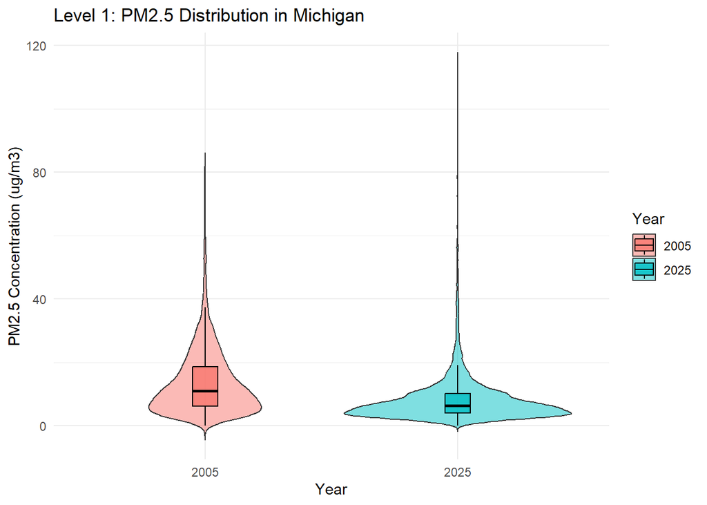

```r
# 2. Visualization: Violin Plot + Boxplot
ggplot(pm_all, aes(x = Year, y = PM2.5, fill = Year)) +
  geom_violin(alpha = 0.5, trim = FALSE) +
  geom_boxplot(width = 0.1, color = "black", alpha = 0.8, outlier.shape = NA) +
  theme_minimal() +
  labs(title = "Level 1: PM2.5 Distribution in Michigan",
       y = "PM2.5 Concentration (ug/m3)")
```

```r
# Level 2
# 1. Summary Statistics by County
county_stats <- pm_all %>%
  group_by(County, Year) %>%
  summarise(Mean_PM = mean(PM2.5, na.rm = TRUE), .groups = "drop")

print(county_stats)
```

```
# A tibble: 40 × 3
   County    Year  Mean_PM
   <chr>     <chr>   <dbl>
 1 Allegan   2005    12.7
 2 Allegan   2025     8.95
 3 Bay       2005    12.4
 4 Bay       2025     8.54
 5 Berrien   2005    13.1
 6 Chippewa  2005     8.25
 7 Dickinson 2005     7.32
 8 Genesee   2005    12.9
 9 Genesee   2025     6.54
10 Ingham    2005    13.5
# ℹ 30 more rows
```

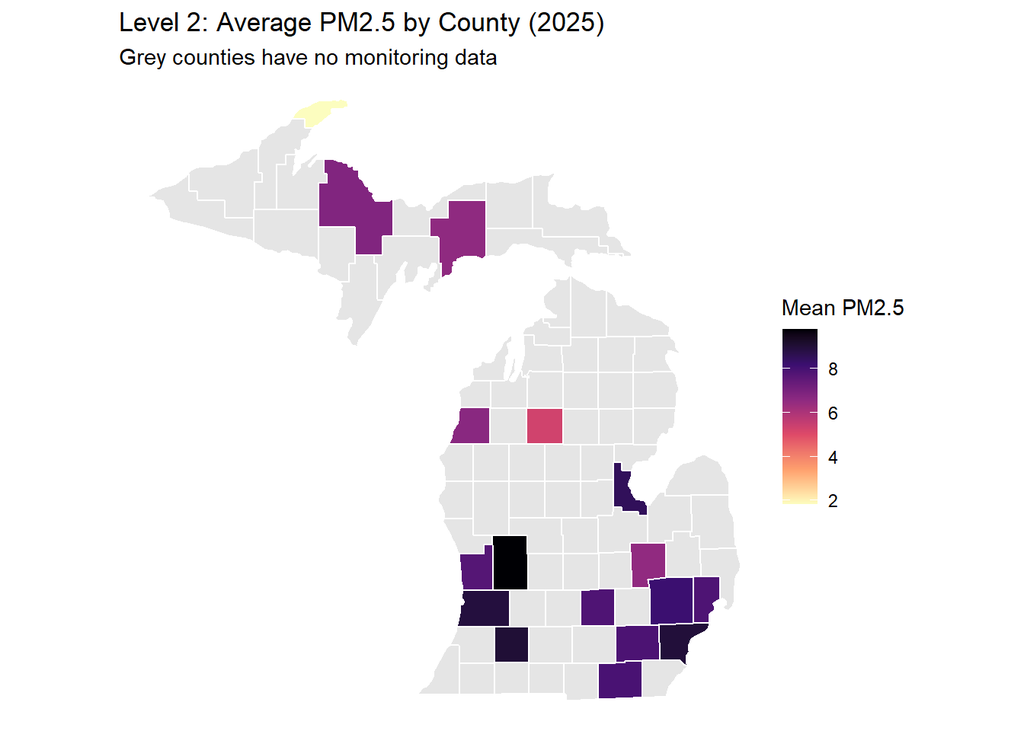

```r
# 2. Prepare Data for the Map (Focusing on 2025)
# Get Michigan county polygon data
mi_counties <- map_data("county", "michigan")

# Prepare 2025 data for merging
map_data_2025 <- county_stats %>%
  filter(Year == "2025") %>%
  mutate(subregion = tolower(County))

# Prepare 2005 data for merging
map_data_2005 <- county_stats %>%
  filter(Year == "2005") %>%
  mutate(subregion = tolower(County))

# Merge data
merged_map_data2025 <- left_join(mi_counties, map_data_2025, by = "subregion")
merged_map_data2005 <- left_join(mi_counties, map_data_2005, by = "subregion")

# Spatial Plot: 2025
ggplot(merged_map_data2025, aes(x = long, y = lat, group = group, fill = Mean_PM)) +
  geom_polygon(color = "white") +
  coord_quickmap() +
  scale_fill_viridis_c(option = "magma", direction = -1, name = "Mean PM2.5", na.value = "grey90") +
  theme_void() +
  labs(title = "Level 2: Average PM2.5 by County (2025)",
       subtitle = "Grey counties have no monitoring data")
```

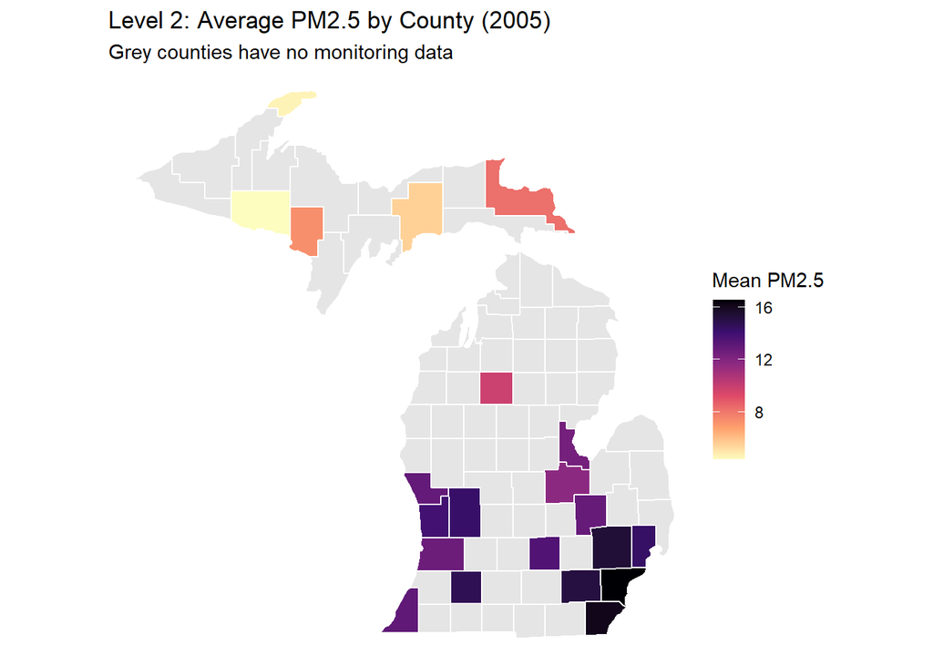

```r
# Spatial Plot: 2005
ggplot(merged_map_data2005, aes(x = long, y = lat, group = group, fill = Mean_PM)) +
  geom_polygon(color = "white") +
  coord_quickmap() +
  scale_fill_viridis_c(option = "magma", direction = -1, name = "Mean PM2.5", na.value = "grey90") +
  theme_void() +
  labs(title = "Level 2: Average PM2.5 by County (2005)",
       subtitle = "Grey counties have no monitoring data")
```

```r
# Level 3
# Filter Data and Summarize by Site
wayne_sites <- pm_all %>%
  filter(County == "Wayne") %>%
  group_by(SiteName, Site.Longitude, Site.Latitude, Year) %>%
  summarise(Mean_PM = mean(PM2.5, na.rm = TRUE), .groups = "drop")
print(head(wayne_sites))
```

```
# A tibble: 6 × 5
  SiteName                     Site.Longitude Site.Latitude Year  Mean_PM
  <chr>                                 <dbl>         <dbl> <chr>   <dbl>
1 ""                                    -83.2          42.3 2005    19.6
2 "92 FEET FROM WHE STREET"             -83.2          42.2 2005    16.4
3 "Allen Park"                          -83.2          42.2 2005    16.3
4 "Allen Park"                          -83.2          42.2 2025     7.96
5 "DET-LINWOOD"                         -83.1          42.4 2005    16.0
6 "DETROIT-SOUTHWEST (DET-SW)"          -83.1          42.3 2005    17.2
```

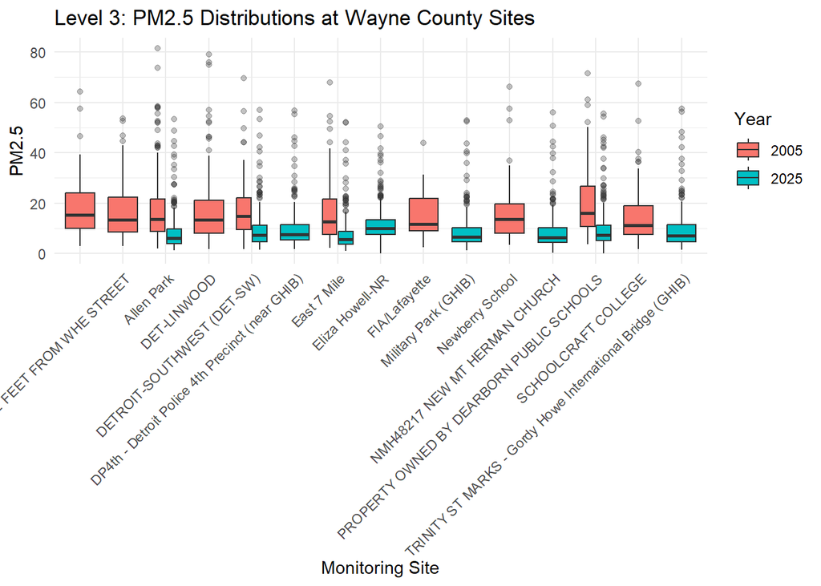

```r
# Visualization: Boxplots by Site
ggplot(filter(pm_all, County == "Wayne"), aes(x = SiteName, y = PM2.5, fill = Year)) +
  geom_boxplot(outlier.alpha = 0.3) +
  theme_minimal() +
  theme(axis.text.x = element_text(angle = 45, hjust = 1)) +
  labs(title = "Level 3: PM2.5 Distributions at Wayne County Sites",
       x = "Monitoring Site")
```

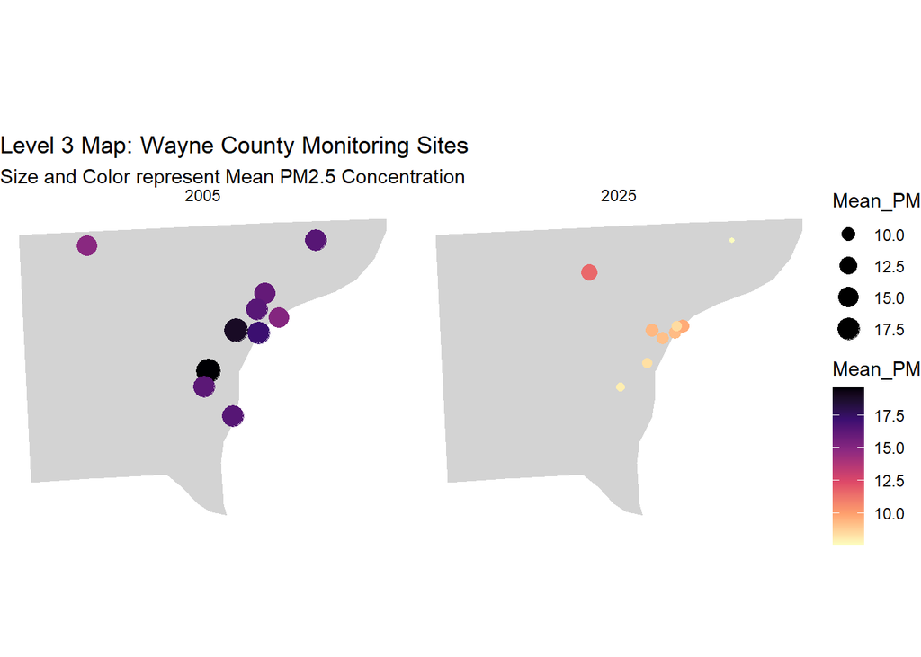

```r
# Spatial Plot: Site Locations in Wayne County
# Get the background map for just Wayne County
wayne_map_bg <- subset(map_data("county", "michigan"), subregion == "wayne")

ggplot() +
  geom_polygon(data = wayne_map_bg, aes(x = long, y = lat, group = group),
               fill = "lightgrey", color = "white") +
  geom_point(data = wayne_sites,
             aes(x = Site.Longitude, y = Site.Latitude, size = Mean_PM, color = Mean_PM)) +
  facet_wrap(~Year) +
  scale_color_viridis_c(option = "magma", direction = -1) +
  coord_quickmap() +
  theme_void() +
  labs(title = "Level 3 Map: Wayne County Monitoring Sites",
       subtitle = "Size and Color represent Mean PM2.5 Concentration")
```

Ans: Level 1: Air quality in Michigan improved between 2005 and 2025, with the mean PM2.5 concentration dropping by roughly 40% (from 13.8 to 8.31 ug/m^3). The violin plots illustrate a major shift in density.